# BLM Data Entry

Cecilia Albert-Black

2025-11-13

# Objective

The objective of this file is to create a data entry files to run the Biotic Ligand Model (BLM) desktop version.

We’ll be creating 2 BLM data entry files for each trace element:

- BLM_Data_Entry_for_Zn.xlsx
- BLM_Data_Entry_for_Cu.xlsx

These files will be used for running BLM as a closed-system (input DIC) in Speciation and Toxicity prediction modes.

See BLM_manual.pdf to learn how to use the BLM.

The BLM requires the following variables to run:

- Site Name
- Sample Name
- Temperature (C)
- pH
- Metal concentration (ug/L)
- Dissolved organic carbon concentration (DOC mg C/L)
- Humic acid (HA %)
- Calcium concentration (Ca mg/L)
- Magnesium concentration (Mg mg/L)
- Sodium concentration (Na mg/L)
- Potassium concentration (K mg/L)
- Sulfate concentration (SO4 mg/L)
- Chloride concentration (Cl mg/L)
- Alkalinity as dissolved inorganic carbon concentration (DIC mg/L)
- Sulfur concentration (S mg/L): under development, but must enter an arbitrary small quantity

We will be obtaining these variables from the WaDE_Synoptic_Summary_Final.xlsx file.

# Creating BLM-Input Datasets

## 1. Import the WaDE Synoptic Survey Dataset

Set working directory

```r
setwd("C:/Users/q4q/OneDrive - Oak Ridge National Laboratory/Research/Bioavailability Project/1. Spatial Assessment/Data/Spatial Assessment of Bioavailability Project/1. Running BLM/Data inputs")
```

Import data from the tab called WaDE_SYNOPTIC_SUMMARY in the WaDE_Synoptic_Summary_Final.xlsx file

```r
library(readxl)

WaDE_Synoptic_Summary <- read_excel("C:/Users/q4q/OneDrive - Oak Ridge National Laboratory/Research/Bioavailability Project/1. Spatial Assessment/Data/Spatial Assessment of Bioavailability Project/1. Running BLM/Data inputs/WaDE_Synoptic_Summary.xlsx",
    sheet = "WaDE_SYNOPTIC_SUMMARY")
head(WaDE_Synoptic_Summary)
```

```
## # A tibble: 6 × 133
##   Sample_ID Site   Theme Regime  Date                DateTime            Sampler
##   <chr>     <chr>  <dbl> <chr>   <dttm>              <dttm>              <chr>
## 1 WaDE_1    BSL1.1     1 Perenn… 2023-04-12 00:00:00 2023-04-12 09:30:00 Herndon
## 2 WaDE_2    BSL2.1     1 Perenn… 2023-04-12 00:00:00 2023-04-12 09:50:00 Herndon
## 3 WaDE_3    BSL2.2     1 Perenn… 2023-04-12 00:00:00 2023-04-12 10:10:00 Herndon
## 4 WaDE_5    BSL3.1     1 Perenn… 2023-04-12 00:00:00 2023-04-12 10:45:00 Herndon
## 5 WaDE_6    BSL3.3     1 Perenn… 2023-04-12 00:00:00 2023-04-12 10:55:00 Herndon
## 6 WaDE_7    BSL3.2     1 Perenn… 2023-04-12 00:00:00 2023-04-12 11:00:00 Herndon
## # ℹ 126 more variables: Water_presence <chr>, Flow_state <chr>, Depth <dbl>,
## #   DO <dbl>, DO_FLAG <dbl>, DOsat <dbl>, DOsat_FLAG <dbl>, pH <dbl>,
## #   pH_FLAG <dbl>, SpecCond <dbl>, SpecCond_FLAG <dbl>, Temp <dbl>,
## #   Temp_FLAG <dbl>, DOC <dbl>, DOC_FLAG <dbl>, DIC <dbl>, DIC_FLAG <dbl>,
## #   Br <dbl>, Br_FLAG <dbl>, Cl <dbl>, Cl_FLAG <dbl>, NO3IC <dbl>,
## #   NO3_FLAG...30 <dbl>, PO4 <dbl>, PO4_FLAG <dbl>, SO4 <dbl>, SO4_FLAG <dbl>,
## #   NH4 <chr>, NH4_FLAG <dbl>, NO3SEAL <chr>, NO3_FLAG...38 <dbl>, SRP <chr>, …
```

Inspect the structure

```r
str(WaDE_Synoptic_Summary)
```

```
## tibble [629 × 133] (S3: tbl_df/tbl/data.frame)
##  $ Sample_ID     : chr [1:629] "WaDE_1" "WaDE_2" "WaDE_3" "WaDE_5" ...
##  $ Site          : chr [1:629] "BSL1.1" "BSL2.1" "BSL2.2" "BSL3.1" ...
##  $ Theme         : num [1:629] 1 1 1 1 1 1 1 1 1 1 ...
##  $ Regime        : chr [1:629] "Perennial" "Perennial" "Perennial" "Perennial" ...
##  $ Date          : POSIXct[1:629], format: "2023-04-12" "2023-04-12" ...
##  $ DateTime      : POSIXct[1:629], format: "2023-04-12 09:30:00" "2023-04-12 09:50:00" ...
##  $ Sampler       : chr [1:629] "Herndon" "Herndon" "Herndon" "Herndon" ...
##  $ Water_presence: chr [1:629] "Y" "Y" "Y" "Y" ...
##  $ Flow_state    : chr [1:629] "Flowing" "Flowing" "Flowing" "Flowing" ...
##  $ Depth         : num [1:629] -9999 -9999 -9999 -9999 -9999 ...
##  $ DO            : num [1:629] -9999 -9999 -9999 -9999 -9999 ...
##  $ DO_FLAG       : num [1:629] -1 -1 -1 -1 -1 -1 -1 -1 -1 -1 ...
##  $ DOsat         : num [1:629] -9999 -9999 -9999 -9999 -9999 ...
##  $ DOsat_FLAG    : num [1:629] -1 -1 -1 -1 -1 -1 -1 -1 -1 -1 ...
```

[output cut: 86 more lines]

Add units to variables according to the README tab

```r
library(dplyr)
# For simplicity, only add units to variables of interest
WaDE_Synoptic_Summary  <-
  WaDE_Synoptic_Summary %>%
  dplyr::rename(
      Temp_C = Temp,
      Zn_uM = Zn,
      Cu_uM = Cu,
      DOC_uM = DOC,
      Ca_uM = Ca,
      Mg_uM = Mg,
      Na_uM = Na,
      K_uM = K,
      SO4_uM = SO4,
      Cl_uM = Cl,
      DIC_uM = DIC
    )

# Check
head(WaDE_Synoptic_Summary)
```

```
## # A tibble: 6 × 133
##   Sample_ID Site   Theme Regime  Date                DateTime            Sampler
##   <chr>     <chr>  <dbl> <chr>   <dttm>              <dttm>              <chr>
## 1 WaDE_1    BSL1.1     1 Perenn… 2023-04-12 00:00:00 2023-04-12 09:30:00 Herndon
## 2 WaDE_2    BSL2.1     1 Perenn… 2023-04-12 00:00:00 2023-04-12 09:50:00 Herndon
## 3 WaDE_3    BSL2.2     1 Perenn… 2023-04-12 00:00:00 2023-04-12 10:10:00 Herndon
## 4 WaDE_5    BSL3.1     1 Perenn… 2023-04-12 00:00:00 2023-04-12 10:45:00 Herndon
## 5 WaDE_6    BSL3.3     1 Perenn… 2023-04-12 00:00:00 2023-04-12 10:55:00 Herndon
## 6 WaDE_7    BSL3.2     1 Perenn… 2023-04-12 00:00:00 2023-04-12 11:00:00 Herndon
## # ℹ 126 more variables: Water_presence <chr>, Flow_state <chr>, Depth <dbl>,
## #   DO <dbl>, DO_FLAG <dbl>, DOsat <dbl>, DOsat_FLAG <dbl>, pH <dbl>,
## #   pH_FLAG <dbl>, SpecCond <dbl>, SpecCond_FLAG <dbl>, Temp_C <dbl>,
## #   Temp_FLAG <dbl>, DOC_uM <dbl>, DOC_FLAG <dbl>, DIC_uM <dbl>,
## #   DIC_FLAG <dbl>, Br <dbl>, Br_FLAG <dbl>, Cl_uM <dbl>, Cl_FLAG <dbl>,
## #   NO3IC <dbl>, NO3_FLAG...30 <dbl>, PO4 <dbl>, PO4_FLAG <dbl>, SO4_uM <dbl>,
## #   SO4_FLAG <dbl>, NH4 <chr>, NH4_FLAG <dbl>, NO3SEAL <chr>, …
```

Count the number of total samples

```r
n_total <- length(unique(WaDE_Synoptic_Summary$Sample_ID))
n_total
```

```
## [1] 629
```

## 2. Omitting Samples

Samples will be omitted which do not have all BLM input variables.

Missing sample measurements are denoted with -9999 values.

```r
library(dplyr)

vars <- c(
  "Temp_C","Zn_uM","Cu_uM","DOC_uM","Ca_uM","Mg_uM",
  "Na_uM","K_uM","SO4_uM","Cl_uM","DIC_uM"
)

missing_dat <- WaDE_Synoptic_Summary %>%
  filter(if_any(all_of(vars), ~ .x == -9999)) %>%
  dplyr::select(Sample_ID, Site, all_of(vars))

missing_dat
```

```
## # A tibble: 243 × 13
##    Sample_ID Site   Temp_C  Zn_uM   Cu_uM DOC_uM Ca_uM Mg_uM Na_uM  K_uM SO4_uM
##    <chr>     <chr>   <dbl>  <dbl>   <dbl>  <dbl> <dbl> <dbl> <dbl> <dbl>  <dbl>
##  1 WaDE_1    BSL1.1   13.3 0.0561 0.0049    71.7  1438   576   193  27     77.5
##  2 WaDE_2    BSL2.1   13.9 0.064  0.00322   65    1290   613   195  26.6   54.7
##  3 WaDE_3    BSL2.2   14.5 0.0641 0.00741  134.   2029   389   288  31.9  132
##  4 WaDE_5    BSL3.1   15.2 0.0537 0.00235   41.7  1202   640   144  26.2   45.7
##  5 WaDE_6    BSL3.3   15.2 0.0571 0.00275   34.2  1079   646   135  29     39.5
##  6 WaDE_7    BSL3.2   15.5 0.0322 0.00291   53.3  1428   610   166  21.3   64
##  7 WaDE_8    BSL4.1   12.7 0.0947 0.00844  168.   3036   734   541  45.7  190
##  8 WaDE_10   MCA3.3   13.7 0.131  0.184     57.5   242   124   144  28     75.8
##  9 WaDE_11   MCA3.1   15   0.0243 0.00184   63.3   664   360   128  21.1   56.2
## 10 WaDE_12   MCA2     18.1 0.0289 0.00254   86.7   641   337    75  21     33.4
## # ℹ 233 more rows
## # ℹ 2 more variables: Cl_uM <dbl>, DIC_uM <dbl>
```

Summarize missing sample measurements

```r
# Number of affected samples
n_missing <- nrow(missing_dat)

# Variables most affected
variable_counts <- colSums(missing_dat[vars] == -9999, na.rm = TRUE)

n_missing # total numer of samples with at least 1 missing variable measurement
```

```
## [1] 243
```

```r
variable_counts # number of missing values by variable
```

```
## Temp_C  Zn_uM  Cu_uM DOC_uM  Ca_uM  Mg_uM  Na_uM   K_uM SO4_uM  Cl_uM DIC_uM
##    201    201    201    202    201    201    201    201    201    201    243
```

Remove these from the WaDE_Synoptic_Summary

```r
WaDE_Synoptic_Summary <- WaDE_Synoptic_Summary %>%
  filter(!if_any(all_of(vars), ~ .x == -9999))

# Count number of samples leftover
n_samples <- nrow(WaDE_Synoptic_Summary)
n_samples
```

```
## [1] 386
```

Build a summary table and export to Excel

```r
library(openxlsx)

# 1. Create a new Excel workbook
wb <- createWorkbook()

# 2. Add a worksheet called "Filtered Samples"
addWorksheet(wb, "Filtered Samples")

# 3. Make a small summary table of your counts
summary_table <- data.frame(
  Metric = c(
    "Total unique samples before filtering",
    "Samples with missing values of BLM vars",
    "Samples remaining after filtering"
  ),
  Value = c(n_total, n_missing, n_samples)
)

# 4. Make a table for the number of -9999 values per variable
variable_counts_table <- data.frame(
  Variable = names(variable_counts),
  N_missing_9999 = as.integer(variable_counts)
)

# 5. Write the summary table at the top of the sheet (row 1)
writeData(
  wb,
  sheet = "Filtered Samples",
  x = summary_table,
  startRow = 1,
  startCol = 1
)

# 6. Write the variable_counts table a bit lower (row 6)
writeData(
  wb,
  sheet = "Filtered Samples",
  x = variable_counts_table,
  startRow = 6,
  startCol = 1
)

# 7. Write the full missing_dat table further down
start_row_missing_dat <- 6 + nrow(variable_counts_table) + 3

writeData(
  wb,
  sheet = "Filtered Samples",
  x = missing_dat,
  startRow = start_row_missing_dat,
  startCol = 1
)

# 8. Save the workbook as an .xlsx file
saveWorkbook(wb, "Omitted_Samples.xlsx", overwrite = TRUE)
```

## 3. Handling Values Below Detection Limit

Values below detection limits (DL) were handled based on two scenarios:

1. **Field DL**: calculated as 3 standard deviations above field blank mean value, excluding outlier values
   - **If concentration > field DL**: flagged above detection limit (ADL) and retained as-is
   - **If 0 < concentrations < field DL**: flagged below detection limit (BDL) and retained as-is
   - **If concentration = 0**: flag as ZV and replaced by the lowest reported value of that element
   - **If concentration < 0**: flagged as negative (NV) and replaced by the lowest reported value of that element
2. **Instrument DL**: used for ions that did not have a field DL (i.e. Cl and SO4)
   - **If concentration > instrument DL**: flagged above detection limit (ADL) and retained as-is
   - **If 0 < concentration < instrument DL**: flag as BDL and left as-is
   - **If concentration = 0**: flag as ZV and replace with ½ the instrument DL
   - **If concentration < 0**: flagged as negative (NV) and replaced with ½ the instrument DL

The reasoning for omitting 0 and negative values is because

1. They are likely inaccurate
2. The BLM cannot handle 0 and negative values

### I. Zinc

Flag and replace the values according to scenario 1 and refer to the Detection Limits tab in WaDE_Synoptic_Summary.xlsx to obtain the field DL value

```r
library(dplyr)

# 1. Define the field detection limit for Zn in uM
Zn_DL_uM <- 6.69E-02

# 2. Find the lowest reported positive Zn_uM value
lowest_Zn_uM <- WaDE_Synoptic_Summary %>%
  filter(!is.na(Zn_uM), Zn_uM > 0) %>%
  summarise(min_Zn = min(Zn_uM)) %>%
  pull(min_Zn)

lowest_Zn_uM
```

```
## [1] 0.000627
```

```r
# 3. Apply detection-limit rules for Zn
WaDE_Synoptic_Summary <- WaDE_Synoptic_Summary %>%
  mutate(
    # Flag column for Zn based on your rules
    Zn_flag = case_when(
      Zn_uM < 0 ~ "NV",                       # negative values
      Zn_uM == 0 ~ "ZV",                      # zero values
      Zn_uM > 0 & Zn_uM < Zn_DL_uM ~ "BDL",   # 0 < conc < DL
      Zn_uM >= Zn_DL_uM ~ "ADL"               # ≥ DL = above detection limit
    ),

    # Overwrite Zn variable based on your replacement rules
    Zn_uM = case_when(
      Zn_uM < 0 ~ lowest_Zn_uM,           # NV → lowest reported positive Zn
      Zn_uM == 0 ~ lowest_Zn_uM,          # ZV → lowest reported positive Zn
      TRUE ~ Zn_uM                        # BDL and ADL retained as-is
    )
  )

# Inspect all assigned flags
table(WaDE_Synoptic_Summary$Zn_flag, useNA = "ifany")
```

```
##
## ADL BDL
## 265 121
```

Histogram of measured Zn (uM) with the field DL

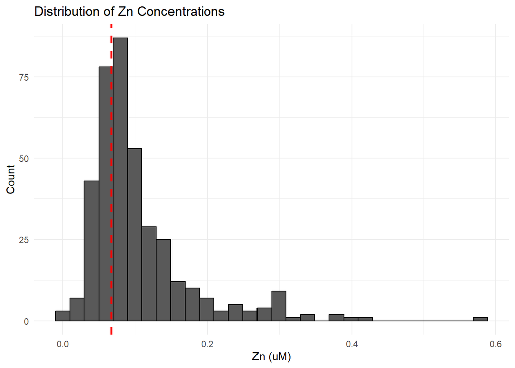

```r
library(ggplot2)

Zn_DL_uM <- 6.69E-02  # Detection limit

hist_zn <- ggplot(WaDE_Synoptic_Summary, aes(x = Zn_uM)) +
  geom_histogram(
    bins = 30,
    color = "black"
  ) +
  geom_vline(
    aes(xintercept = Zn_DL_uM),
    linetype = "dashed",
    linewidth = 1,
    color = "red"
  ) +
  labs(
    title = "Distribution of Zn Concentrations",
    x = "Zn (uM)",
    y = "Count"
  ) +
  theme_minimal()

hist_zn
```

### II. Copper

Flag and replace the values according to scenario 1 and refer to the Detection Limits tab in WaDE_Synoptic_Summary.xlsx to obtain the field DL value

```r
library(dplyr)

# 1. Define the field detection limit for Zn in uM
Cu_DL_uM <- 2.22E-03

# 2. Find the lowest reported positive Zn_uM value
lowest_Cu_uM <- WaDE_Synoptic_Summary %>%
  filter(!is.na(Cu_uM), Cu_uM > 0) %>%
  summarise(min_Cu = min(Cu_uM)) %>%
  pull(min_Cu)

lowest_Cu_uM
```

```
## [1] 0.000149
```

```r
# 3. Apply detection-limit rules for Zn
WaDE_Synoptic_Summary <- WaDE_Synoptic_Summary %>%
  mutate(
    # Flag column for Zn based on your rules
    Cu_flag = case_when(
      Cu_uM < 0 ~ "NV",                       # negative values
      Cu_uM == 0 ~ "ZV",                      # zero values
      Cu_uM > 0 & Cu_uM < Cu_DL_uM ~ "BDL",   # 0 < conc < DL
      Cu_uM >= Cu_DL_uM ~ "ADL"               # ≥ DL = above detection limit
    ),

    # Overwrite Zn variable based on your replacement rules
    Cu_uM = case_when(
      Cu_uM < 0 ~ lowest_Cu_uM,           # NV → lowest reported positive Zn
      Cu_uM == 0 ~ lowest_Cu_uM,          # ZV → lowest reported positive Zn
      TRUE ~ Cu_uM                        # BDL and ADL retained as-is
    )
  )

# Inspect all assigned flags
table(WaDE_Synoptic_Summary$Cu_flag, useNA = "ifany")
```

```
##
## ADL BDL  ZV
## 332  48   6
```

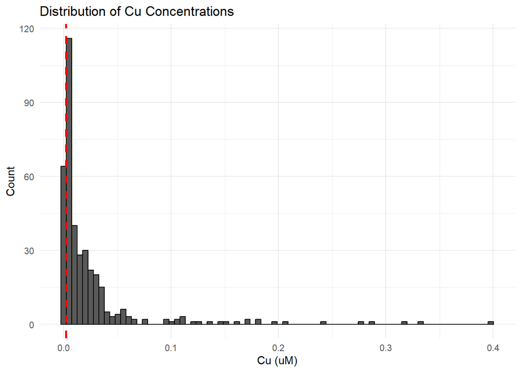

```r
hist_cu <- ggplot(WaDE_Synoptic_Summary, aes(x = Cu_uM)) +
  geom_histogram(
    bins = 80,
    color = "black"
  ) +
  geom_vline(
    aes(xintercept = Cu_DL_uM),
    linetype = "dashed",
    linewidth = 1,
    color = "red"
  ) +
  labs(
    title = "Distribution of Cu Concentrations",
    x = "Cu (uM)",
    y = "Count"
  ) +
  theme_minimal()

hist_cu
```

### III. Sulfate

Flag and replace the values according to scenario 2 and refer to the README tab in WaDE_Synoptic_Summary.xlsx for the instrument DL value.

```r
library(dplyr)

# 1. Define the instrument DL for sulfate in uM
SO4_DL_uM <- 1.7
SO4_half_DL_uM <- SO4_DL_uM / 2   # ½ the instrument DL

# 2. Apply detection-limit rules for sulfate
WaDE_Synoptic_Summary <- WaDE_Synoptic_Summary %>%
  mutate(
    # Flag column for sulfate
    SO4_flag = case_when(
      is.na(SO4_uM) ~ NA_character_,                # missing
      SO4_uM < 0 ~ "NV",                            # negative values (NV)
      SO4_uM == 0 ~ "ZV",                           # zero values (ZV)
      SO4_uM > 0 & SO4_uM < SO4_DL_uM ~ "BDL",      # 0 < conc < DL (BDL)
      SO4_uM >= SO4_DL_uM ~ "ADL"                   # ≥ DL = above detection limit
    ),

    # Adjusted sulfate values
    SO4_uM = case_when(
      SO4_uM < 0 ~ SO4_half_DL_uM,       # NV → replace with ½ instrument DL
      SO4_uM == 0 ~ SO4_half_DL_uM,      # ZV → replace with ½ instrument DL
      TRUE ~ SO4_uM                      # BDL and ADL retained as-is
    )
  )

# Inspect
table(WaDE_Synoptic_Summary$SO4_flag, useNA = "ifany")
```

```
##
## ADL  ZV
## 384   2
```

Histogram with instrument DL

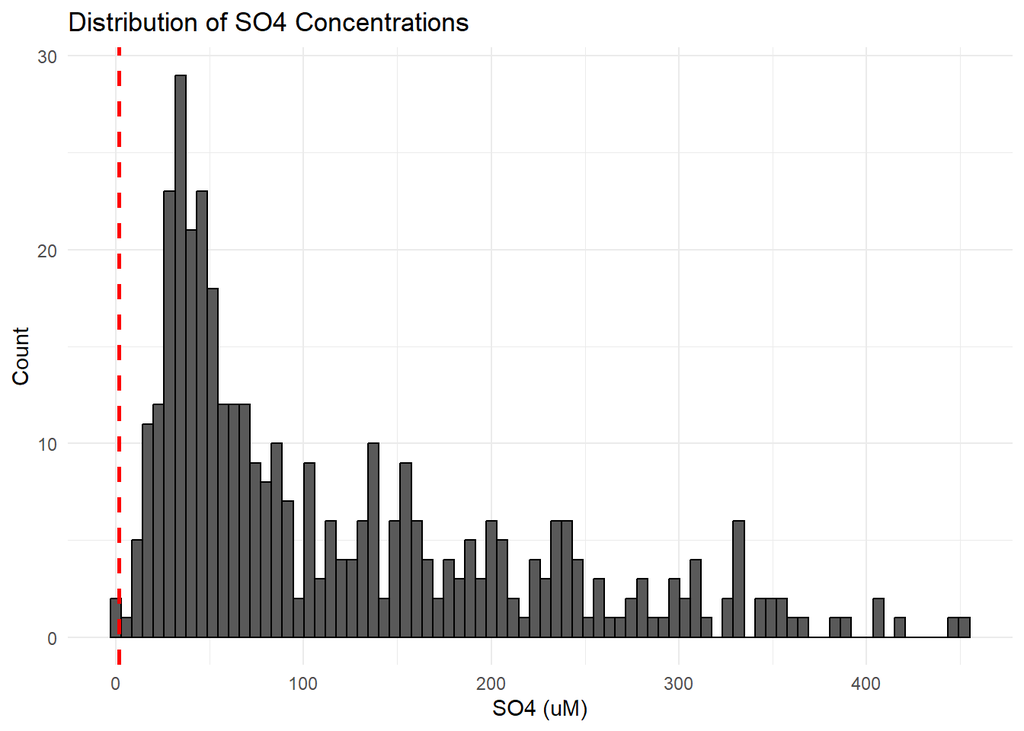

```r
hist_so4 <- ggplot(WaDE_Synoptic_Summary, aes(x = SO4_uM)) +
  geom_histogram(
    bins = 80,
    color = "black"
  ) +
  geom_vline(
    aes(xintercept = SO4_DL_uM),
    linetype = "dashed",
    linewidth = 1,
    color = "red"
  ) +
  labs(
    title = "Distribution of SO4 Concentrations",
    x = "SO4 (uM)",
    y = "Count"
  ) +
  theme_minimal()

hist_so4
```

### IV. Chloride

Instrument DL: 22.9 uM

```r
# 1. Define the instrument detection limit for chloride in uM
Cl_DL_uM <- 2.29e1              # instrument DL = 22.9 uM
Cl_half_DL_uM <- Cl_DL_uM / 2   # ½ the instrument DL

# 2. Apply detection-limit rules for chloride
WaDE_Synoptic_Summary <- WaDE_Synoptic_Summary %>%
  mutate(
    # Flag column for chloride
    Cl_flag = case_when(
      Cl_uM < 0 ~ "NV",                           # negative values → NV
      Cl_uM == 0 ~ "ZV",                          # zero values → ZV
      Cl_uM > 0 & Cl_uM < Cl_DL_uM ~ "BDL",       # 0 < conc < DL → BDL
      Cl_uM >= Cl_DL_uM ~ "ADL"                   # ≥ DL = above detection limit
    ),

    # Adjusted chloride values
    Cl_uM = case_when(
      Cl_uM < 0 ~ Cl_half_DL_uM,        # NV → replace with ½ instrument DL
      Cl_uM == 0 ~ Cl_half_DL_uM,       # ZV → replace with ½ instrument DL
      TRUE ~ Cl_uM                      # BDL and ADL retained as-is
    )
  )

# Inspect
table(WaDE_Synoptic_Summary$Cl_flag, useNA = "ifany")
```

```
##
## ADL BDL  ZV
## 377   4   5
```

Histogram with instrument DL

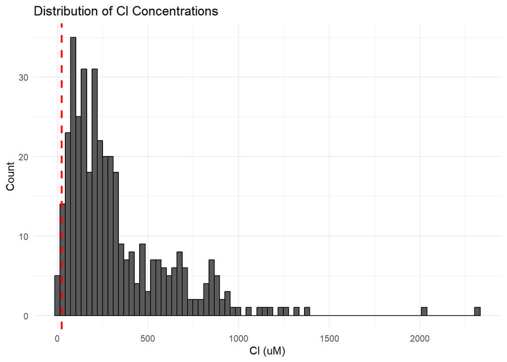

```r
hist_cl <- ggplot(WaDE_Synoptic_Summary, aes(x = Cl_uM)) +
  geom_histogram(
    bins = 80,
    color = "black"
  ) +
  geom_vline(
    aes(xintercept = Cl_DL_uM),
    linetype = "dashed",
    linewidth = 1,
    color = "red"
  ) +
  labs(
    title = "Distribution of Cl Concentrations",
    x = "Cl (uM)",
    y = "Count"
  ) +
  theme_minimal()

hist_cl
```

## 4. Export Clean Dataset

Create a clean WaDE Synoptic Survey Dataset

```r
library(writexl)

# Zinc
write_xlsx(WaDE_Synoptic_Summary, "WaDE_Synoptic_Summary_Clean.xlsx")
```

## 5. Select BLM Input Variables

Select variables to create separate BLM data inputs for Zn and Cu:

```r
library(dplyr)
library(rlang)

# 1. Create a loop function to create a data frame for any BLM element of choice

create_blm_input <- function(df, metal){

  metal_sym <- sym(metal)

  df %>%
    dplyr::select(
      Sample_ID,
      Site,
      Temp_C,
      pH,
      !!metal_sym,
      DOC_uM,
      Ca_uM,
      Mg_uM,
      Na_uM,
      K_uM,
      SO4_uM,
      Cl_uM,
      DIC_uM
    )
}

# 2. Run it for the following trace elements
zn_blm_input_df <- create_blm_input(WaDE_Synoptic_Summary, "Zn_uM")
cu_blm_input_df <- create_blm_input(WaDE_Synoptic_Summary, "Cu_uM")

# 3. Check the results
head(zn_blm_input_df)
```

```
## # A tibble: 6 × 13
##   Sample_ID Site    Temp_C    pH  Zn_uM DOC_uM Ca_uM Mg_uM Na_uM  K_uM SO4_uM
##   <chr>     <chr>    <dbl> <dbl>  <dbl>  <dbl> <dbl> <dbl> <dbl> <dbl>  <dbl>
## 1 WaDE_62   MTN1.1    16.5  7.21 0.036    75.8  1498 458     212  37     38.2
## 2 WaDE_63   EFK13.8   18.6  8.28 0.0282  160    1338 333     295  54    139
## 3 WaDE_64   MTN4      15.8  8.29 0.115    35.8   271 182      90  24.8   29.7
## 4 WaDE_65   MTN2      18.7  8.32 0.0707  528.    306  75.6     7  46.4    7.5
## 5 WaDE_66   MCA3.3    16.2  7.67 0.0316  119.    164  79.9    88  21.2   54.3
## 6 WaDE_67   MCA3.2    16.5  7.49 0.0819   81.7    46  24.7    66  12.2   37.1
## # ℹ 2 more variables: Cl_uM <dbl>, DIC_uM <dbl>
```

```r
head(cu_blm_input_df)
```

```
## # A tibble: 6 × 13
##   Sample_ID Site    Temp_C    pH    Cu_uM DOC_uM Ca_uM Mg_uM Na_uM  K_uM SO4_uM
##   <chr>     <chr>    <dbl> <dbl>    <dbl>  <dbl> <dbl> <dbl> <dbl> <dbl>  <dbl>
## 1 WaDE_62   MTN1.1    16.5  7.21 0.0026     75.8  1498 458     212  37     38.2
## 2 WaDE_63   EFK13.8   18.6  8.28 0.0174    160    1338 333     295  54    139
## 3 WaDE_64   MTN4      15.8  8.29 0.000488   35.8   271 182      90  24.8   29.7
## 4 WaDE_65   MTN2      18.7  8.32 0.0352    528.    306  75.6     7  46.4    7.5
## 5 WaDE_66   MCA3.3    16.2  7.67 0.000834  119.    164  79.9    88  21.2   54.3
## 6 WaDE_67   MCA3.2    16.5  7.49 0.00335    81.7    46  24.7    66  12.2   37.1
## # ℹ 2 more variables: Cl_uM <dbl>, DIC_uM <dbl>
```

Add a column for humic acid at 10 % after DOC

```r
library(dplyr)

# Zinc
zn_blm_input_df <- zn_blm_input_df %>%
  mutate(
    HA = 10 ) %>%
  relocate(HA,  .after = DOC_uM)

# Copper
cu_blm_input_df <- cu_blm_input_df %>%
  mutate(
    HA = 10 ) %>%
  relocate(HA, .after = DOC_uM)

# Check
head(zn_blm_input_df)
```

```
## # A tibble: 6 × 14
##   Sample_ID Site    Temp_C    pH  Zn_uM DOC_uM    HA Ca_uM Mg_uM Na_uM  K_uM
##   <chr>     <chr>    <dbl> <dbl>  <dbl>  <dbl> <dbl> <dbl> <dbl> <dbl> <dbl>
## 1 WaDE_62   MTN1.1    16.5  7.21 0.036    75.8    10  1498 458     212  37
## 2 WaDE_63   EFK13.8   18.6  8.28 0.0282  160      10  1338 333     295  54
## 3 WaDE_64   MTN4      15.8  8.29 0.115    35.8    10   271 182      90  24.8
## 4 WaDE_65   MTN2      18.7  8.32 0.0707  528.     10   306  75.6     7  46.4
## 5 WaDE_66   MCA3.3    16.2  7.67 0.0316  119.     10   164  79.9    88  21.2
## 6 WaDE_67   MCA3.2    16.5  7.49 0.0819   81.7    10    46  24.7    66  12.2
## # ℹ 3 more variables: SO4_uM <dbl>, Cl_uM <dbl>, DIC_uM <dbl>
```

```r
head(cu_blm_input_df)
```

```
## # A tibble: 6 × 14
##   Sample_ID Site    Temp_C    pH    Cu_uM DOC_uM    HA Ca_uM Mg_uM Na_uM  K_uM
##   <chr>     <chr>    <dbl> <dbl>    <dbl>  <dbl> <dbl> <dbl> <dbl> <dbl> <dbl>
## 1 WaDE_62   MTN1.1    16.5  7.21 0.0026     75.8    10  1498 458     212  37
## 2 WaDE_63   EFK13.8   18.6  8.28 0.0174    160      10  1338 333     295  54
## 3 WaDE_64   MTN4      15.8  8.29 0.000488   35.8    10   271 182      90  24.8
## 4 WaDE_65   MTN2      18.7  8.32 0.0352    528.     10   306  75.6     7  46.4
## 5 WaDE_66   MCA3.3    16.2  7.67 0.000834  119.     10   164  79.9    88  21.2
## 6 WaDE_67   MCA3.2    16.5  7.49 0.00335    81.7    10    46  24.7    66  12.2
## # ℹ 3 more variables: SO4_uM <dbl>, Cl_uM <dbl>, DIC_uM <dbl>
```

Add a column for S at the end

```r
library(dplyr)

# Zinc
zn_blm_input_df <- zn_blm_input_df %>%
  mutate('S_uM' = 1e-10)

# Copper
cu_blm_input_df <- cu_blm_input_df %>%
  mutate('S_uM' = 1e-10)

# Check
summary(zn_blm_input_df$S_uM)
```

```
##    Min. 1st Qu.  Median    Mean 3rd Qu.    Max.
##   1e-10   1e-10   1e-10   1e-10   1e-10   1e-10
```

```r
summary(cu_blm_input_df$S_uM)
```

```
##    Min. 1st Qu.  Median    Mean 3rd Qu.    Max.
##   1e-10   1e-10   1e-10   1e-10   1e-10   1e-10
```

## 4. Unit Conversions

Convert and rewrite trace element units from uM to ug/L

```r
library(dplyr)

# Zinc
zn_blm_input_df <- zn_blm_input_df %>%
  mutate(Zn_uM = Zn_uM * 65.38) %>% # Overwrite Zn (uM) with Zn (ug/L) value
  rename(Zn_ug_L = Zn_uM) # rename AFTER overwriting

# Copper
cu_blm_input_df <- cu_blm_input_df %>%
  mutate(Cu_uM = Cu_uM * 63.546) %>% # Overwrite Zn (uM) with Zn (ug/L) value
  rename(Cu_ug_L = Cu_uM) # rename AFTER overwriting

# Check
str(zn_blm_input_df)
```

```
## tibble [386 × 15] (S3: tbl_df/tbl/data.frame)
##  $ Sample_ID: chr [1:386] "WaDE_62" "WaDE_63" "WaDE_64" "WaDE_65" ...
##  $ Site     : chr [1:386] "MTN1.1" "EFK13.8" "MTN4" "MTN2" ...
##  $ Temp_C   : num [1:386] 16.5 18.6 15.8 18.7 16.2 16.5 17.3 16.8 17.3 19 ...
##  $ pH       : num [1:386] 7.21 8.28 8.29 8.32 7.67 7.49 7.62 7.55 8.13 8.17 ...
##  $ Zn_ug_L  : num [1:386] 2.35 1.84 7.52 4.62 2.07 ...
##  $ DOC_uM   : num [1:386] 75.8 160 35.8 527.5 119.2 ...
##  $ HA       : num [1:386] 10 10 10 10 10 10 10 10 10 10 ...
##  $ Ca_uM    : num [1:386] 1498 1338 271 306 164 ...
##  $ Mg_uM    : num [1:386] 458 333 182 75.6 79.9 24.7 172 237 210 439 ...
##  $ Na_uM    : num [1:386] 212 295 90 7 88 66 95 134 115 398 ...
##  $ K_uM     : num [1:386] 37 54 24.8 46.4 21.2 12.2 22.5 28.1 24.5 60.2 ...
##  $ SO4_uM   : num [1:386] 38.2 139 29.7 7.5 54.3 37.1 21.8 38.8 31.2 203 ...
##  $ Cl_uM    : num [1:386] 174 172 80 16 87 77 80 93 90 246 ...
##  $ DIC_uM   : num [1:386] 4352 955 3223 878 568 ...
##  $ S_uM     : num [1:386] 1e-10 1e-10 1e-10 1e-10 1e-10 ...
```

```r
str(cu_blm_input_df)
```

```
## tibble [386 × 15] (S3: tbl_df/tbl/data.frame)
##  $ Sample_ID: chr [1:386] "WaDE_62" "WaDE_63" "WaDE_64" "WaDE_65" ...
##  $ Site     : chr [1:386] "MTN1.1" "EFK13.8" "MTN4" "MTN2" ...
##  $ Temp_C   : num [1:386] 16.5 18.6 15.8 18.7 16.2 16.5 17.3 16.8 17.3 19 ...
##  $ pH       : num [1:386] 7.21 8.28 8.29 8.32 7.67 7.49 7.62 7.55 8.13 8.17 ...
##  $ Cu_ug_L  : num [1:386] 0.165 1.106 0.031 2.237 0.053 ...
##  $ DOC_uM   : num [1:386] 75.8 160 35.8 527.5 119.2 ...
##  $ HA       : num [1:386] 10 10 10 10 10 10 10 10 10 10 ...
##  $ Ca_uM    : num [1:386] 1498 1338 271 306 164 ...
##  $ Mg_uM    : num [1:386] 458 333 182 75.6 79.9 24.7 172 237 210 439 ...
##  $ Na_uM    : num [1:386] 212 295 90 7 88 66 95 134 115 398 ...
##  $ K_uM     : num [1:386] 37 54 24.8 46.4 21.2 12.2 22.5 28.1 24.5 60.2 ...
##  $ SO4_uM   : num [1:386] 38.2 139 29.7 7.5 54.3 37.1 21.8 38.8 31.2 203 ...
##  $ Cl_uM    : num [1:386] 174 172 80 16 87 77 80 93 90 246 ...
##  $ DIC_uM   : num [1:386] 4352 955 3223 878 568 ...
##  $ S_uM     : num [1:386] 1e-10 1e-10 1e-10 1e-10 1e-10 ...
```

Convert DOC, Ca, Mg, Na, K, Cl, SO4, and S from uM to mg/L

```r
# Zinc
zn_blm_input_df <- zn_blm_input_df %>%
  mutate(
    DOC_uM = DOC_uM * 12.01e-3,
    Ca_uM  = Ca_uM  * 40.078e-3,
    Mg_uM  = Mg_uM  * 24.305e-3,
    Na_uM  = Na_uM  * 22.990e-3,
    K_uM   = K_uM   * 39.098e-3,
    Cl_uM  = Cl_uM  * 35.45e-3,
    SO4_uM = SO4_uM * 96.06e-3,
    S_uM   = S_uM   * 32.06e-3
  ) %>%
  rename(
    DOC_mg_L = DOC_uM,
    Ca_mg_L  = Ca_uM,
    Mg_mg_L  = Mg_uM,
    Na_mg_L  = Na_uM,
    K_mg_L   = K_uM,
    Cl_mg_L  = Cl_uM,
    SO4_mg_L = SO4_uM,
    S_mg_L   = S_uM
  )

# Copper
cu_blm_input_df <- cu_blm_input_df %>%
  mutate(
    DOC_uM = DOC_uM * 12.01e-3,
    Ca_uM  = Ca_uM  * 40.078e-3,
    Mg_uM  = Mg_uM  * 24.305e-3,
    Na_uM  = Na_uM  * 22.990e-3,
    K_uM   = K_uM   * 39.098e-3,
    Cl_uM  = Cl_uM  * 35.45e-3,
    SO4_uM = SO4_uM * 96.06e-3,
    S_uM   = S_uM   * 32.06e-3
  ) %>%
  rename(
    DOC_mg_L = DOC_uM,
    Ca_mg_L  = Ca_uM,
    Mg_mg_L  = Mg_uM,
    Na_mg_L  = Na_uM,
    K_mg_L   = K_uM,
    Cl_mg_L  = Cl_uM,
    SO4_mg_L = SO4_uM,
    S_mg_L   = S_uM
  )

# Check
str(zn_blm_input_df)
```

```
## tibble [386 × 15] (S3: tbl_df/tbl/data.frame)
##  $ Sample_ID: chr [1:386] "WaDE_62" "WaDE_63" "WaDE_64" "WaDE_65" ...
##  $ Site     : chr [1:386] "MTN1.1" "EFK13.8" "MTN4" "MTN2" ...
##  $ Temp_C   : num [1:386] 16.5 18.6 15.8 18.7 16.2 16.5 17.3 16.8 17.3 19 ...
##  $ pH       : num [1:386] 7.21 8.28 8.29 8.32 7.67 7.49 7.62 7.55 8.13 8.17 ...
##  $ Zn_ug_L  : num [1:386] 2.35 1.84 7.52 4.62 2.07 ...
##  $ DOC_mg_L : num [1:386] 0.911 1.922 0.43 6.335 1.431 ...
##  $ HA       : num [1:386] 10 10 10 10 10 10 10 10 10 10 ...
##  $ Ca_mg_L  : num [1:386] 60.04 53.62 10.86 12.26 6.57 ...
##  $ Mg_mg_L  : num [1:386] 11.13 8.09 4.42 1.84 1.94 ...
##  $ Na_mg_L  : num [1:386] 4.874 6.782 2.069 0.161 2.023 ...
##  $ K_mg_L   : num [1:386] 1.447 2.111 0.97 1.814 0.829 ...
##  $ SO4_mg_L : num [1:386] 3.67 13.35 2.85 0.72 5.22 ...
##  $ Cl_mg_L  : num [1:386] 6.168 6.097 2.836 0.567 3.084 ...
##  $ DIC_uM   : num [1:386] 4352 955 3223 878 568 ...
##  $ S_mg_L   : num [1:386] 3.21e-12 3.21e-12 3.21e-12 3.21e-12 3.21e-12 ...
```

```r
str(cu_blm_input_df)
```

```
## tibble [386 × 15] (S3: tbl_df/tbl/data.frame)
##  $ Sample_ID: chr [1:386] "WaDE_62" "WaDE_63" "WaDE_64" "WaDE_65" ...
##  $ Site     : chr [1:386] "MTN1.1" "EFK13.8" "MTN4" "MTN2" ...
##  $ Temp_C   : num [1:386] 16.5 18.6 15.8 18.7 16.2 16.5 17.3 16.8 17.3 19 ...
##  $ pH       : num [1:386] 7.21 8.28 8.29 8.32 7.67 7.49 7.62 7.55 8.13 8.17 ...
##  $ Cu_ug_L  : num [1:386] 0.165 1.106 0.031 2.237 0.053 ...
##  $ DOC_mg_L : num [1:386] 0.911 1.922 0.43 6.335 1.431 ...
##  $ HA       : num [1:386] 10 10 10 10 10 10 10 10 10 10 ...
##  $ Ca_mg_L  : num [1:386] 60.04 53.62 10.86 12.26 6.57 ...
##  $ Mg_mg_L  : num [1:386] 11.13 8.09 4.42 1.84 1.94 ...
##  $ Na_mg_L  : num [1:386] 4.874 6.782 2.069 0.161 2.023 ...
##  $ K_mg_L   : num [1:386] 1.447 2.111 0.97 1.814 0.829 ...
##  $ SO4_mg_L : num [1:386] 3.67 13.35 2.85 0.72 5.22 ...
##  $ Cl_mg_L  : num [1:386] 6.168 6.097 2.836 0.567 3.084 ...
##  $ DIC_uM   : num [1:386] 4352 955 3223 878 568 ...
##  $ S_mg_L   : num [1:386] 3.21e-12 3.21e-12 3.21e-12 3.21e-12 3.21e-12 ...
```

## 5. Export to Excel

```r
library(writexl)

# Zinc
write_xlsx(zn_blm_input_df, "BLM_Data_Entry_for_Zn.xlsx")

# Copper
write_xlsx(cu_blm_input_df, "BLM_Data_Entry_for_Cu.xlsx")
```

## 6. Running the Biotic Ligand Model (BLM)

These two datasets can be used to input into BLM.

*Note: make sure that when running BLM with HA at 80% to change this variable and when running BLM as open system to set this mode in BLM (see manual for details).

## 7. Post-Running the BLM

Once the following datasets have been created, follow the steps in 2. Dataset merging.Rmd